# Data Mining and Analysis In Motorsports

INFO 523 Final Project

Student - James Clover

University of Arizona

Instructor - Cristian Román-Palacios

School of Information, University of Arizona, Tucson, AZ

# Introduction

Motorsports are increasingly data driven, and Formula 1 is the perfect example. Over 2TB of data is generated from a single Formula 1 car over the course of a race weekend, coming from thousands of sensors on the cars and on the track. This data is mined by the teams and drivers to analyze and make improvements to performance and strategy, as well as by the organization to present a story line to the viewers and ensure that all teams and drivers are following the rules and guidelines.

# Purpose

This file will be used to provide easily reproducible code for the presentation in this same GitHub repo. It goes hand-in-hand with the Powerpoint Presentation. While almost all performance data is not released to the public, we can mine what data is available to draw conclusions about how the sport is changing.

### Load Required Libraries

```r
#Search for required packages, install them if not available
list.of.packages <- c("ggplot2", "ggridges", "dplyr", "ggthemes", "viridis", "plotrix")
new.packages <- list.of.packages[!(list.of.packages %in% installed.packages()[,"Package"])]
if(length(new.packages)) install.packages(new.packages)

#Load the required libraries
library(ggplot2)
library(ggridges)
library(plotrix)
library(dplyr)
library(ggthemes)
library(viridis)
```

### Load Required Datasets

```r
#Load the required data tables
RacesOriginal <- read.csv("F1 Database/races.csv")
CircuitsOriginal <- read.csv("F1 Database/circuits.csv")
ResultsOriginal <- read.csv("F1 Database/results.csv")
DriverOriginal <- read.csv("F1 Database/drivers.csv")
```

### Punching the Brakes: Are F1 Cars Slowing Down?

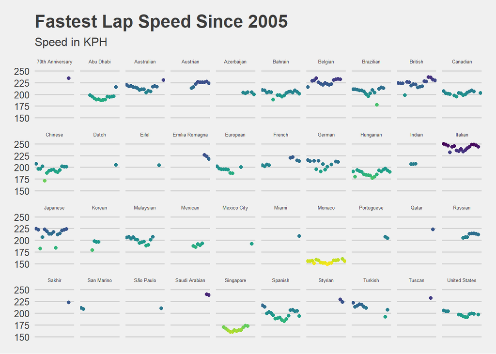

```r
#convert characters to numeric to prevent any errors
ResultsOriginal$fastestLapSpeed <- as.numeric(ResultsOriginal$fastestLapSpeed)

#Subset to only races since 2005
RacesOriginal1 <- subset(RacesOriginal, RacesOriginal$year > 2004)

#Remove unnedeed columns
Races <- RacesOriginal1[,c(1, 2, 4, 5)]
Results <- ResultsOriginal[,c(2, 3, 17)]
Circuits <- CircuitsOriginal[,c(1:5)]

#Merge dataframes above into one useful dataset
FastestLapOriginal <- merge(Races, Results, by = 'raceId')
FastestLap <- merge(FastestLapOriginal, Circuits, by = 'circuitId')

#Remove Grand Prix from Race Names
FastestLap$name.x <- gsub(" Grand Prix", "", FastestLap$name.x)

#Group results into fastest lap by circuit (median speed) since 2005
FastestLapSummary <- FastestLap %>%
  group_by(name.x, year) %>%
  summarize(medianFastestLapSpeed = median(fastestLapSpeed, na.rm = T))

#Create a plot that shows a panel of fastest lap speed on every track during this time period, with a panel for each
FastestLapByCircuitYear <- FastestLapSummary %>% ggplot(aes(x = factor(year), y = medianFastestLapSpeed, color = medianFastestLapSpeed)) +
  geom_point() + theme_fivethirtyeight() +
  scale_color_gradientn(name = "", colours = rev(viridis(30))) + scale_x_discrete(labels = NULL, breaks = NULL) +
  theme(
  strip.text.x = element_text(size = 5)) + facet_wrap(~name.x, ncol = 10) +
  labs(title='Fastest Lap Speed Since 2005',
       subtitle='Speed in KPH',
       x = "Year",
       y = "Fastest Lap Speed") +
  guides(color=FALSE)

#View the plot
FastestLapByCircuitYear
```

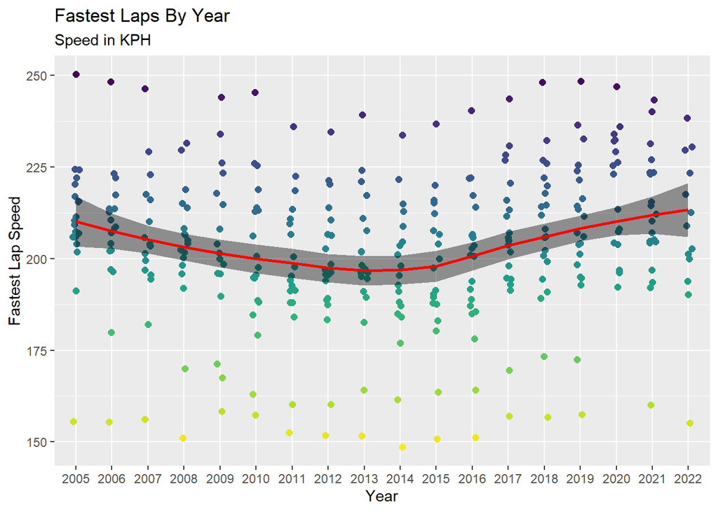

```r
#Convert the data into a scatterplot with a regression line and confidence intervals
FastestLapByYear <- FastestLapSummary %>%
  ggplot(aes(x = factor(year), y = medianFastestLapSpeed, color = medianFastestLapSpeed)) +
  geom_jitter(shape = 16, position = position_jitter(0.1), size = 2) +
  geom_smooth(method = 'loess', aes(group = 1), color = "red", fill = "black", lty = 1, size = 1) +
  scale_color_gradientn(name = "",colours = rev(viridis(10))) +
  labs(title = 'Fastest Laps By Year',
       subtitle = 'Speed in KPH',
       x = "Year",
       y = "Fastest Lap Speed") +
  guides(color = FALSE)

#View the plot
FastestLapByYear
```

### A Young Man’s Game: Are Drivers Getting Younger?

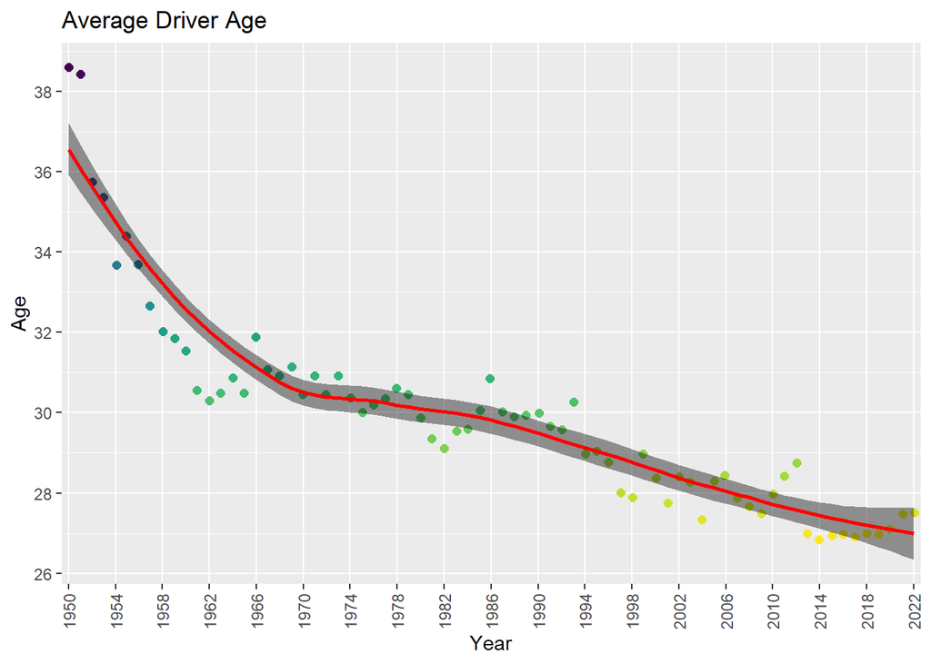

```r
#Remove unnedeed columns
Driver2 <- DriverOriginal[,c(1, 7, 8)]
Results2 <- ResultsOriginal[,c(2:3, 9)]
Races2 <- RacesOriginal[,c(1, 2, 6)]

#Merge dataframes above into one useful dataset
DriverAgeOriginal <- merge(Results2, Driver2, by = 'driverId')
DriverAge <- merge(DriverAgeOriginal, Races2, by = 'raceId')

#Convert Driver Age into a readable format
DriverAge$dob <- as.Date(DriverAge$dob,"%Y-%m-%d")

#Create a new column that substracts date of birth from race date to find year, rounds down to closest integer with "floor"
#Note that difftime has a max unit of weeks, so 52.25 is used to convert to years, accounting for leap years
DriverAge$agerace <- floor(as.numeric(difftime(DriverAge$date, DriverAge$dob, units = "weeks"))/52.25)

#Create a summary of average driver age by year
DriverAgeMean <- DriverAge %>%
  group_by(year) %>%
  summarize(averageage = mean(agerace, na.rm = T))

#Create a trend of average driver age over time
AgeOverTime <- DriverAgeMean %>%
  ggplot(aes(x = factor(year), y = averageage, color = averageage)) +
  geom_jitter(shape = 16, position = position_jitter(0.1), size = 2) +
  geom_smooth(method = 'loess', aes(group = 1), color = 'red', fill = 'black', lty = 1, size = 1) +
  scale_y_continuous(breaks = seq(20, 44, 2)) +
  scale_x_discrete(breaks = seq(1950, 2022, 4)) +
  scale_color_gradientn(name = "",colours = rev(viridis(10))) +
  labs(title = "Average Driver Age",
       x = "Year",
       y = "Age") +
  theme(axis.text.x = element_text(angle = 90, vjust = 0.5, hjust=1)) +
  guides(color = FALSE)

#View the plot
AgeOverTime
```

### What’s Age Got to Do With It: Do Older Drivers Lose Their Skills?

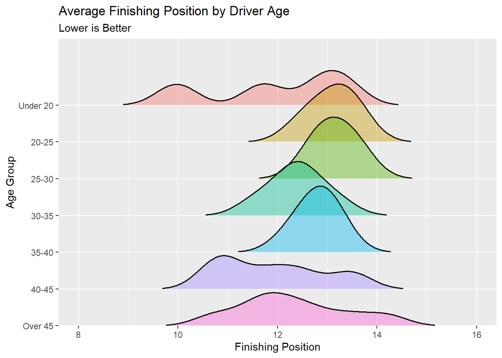

```r
#Remove sparse data, as drivers over 50 have been quite rare
DriverAge2 <- subset(DriverAge, DriverAge$agerace < 60)

#Create a new dataframe that has only the finishing position by age
FinishPositionbyAge <- DriverAge2 %>%
  group_by(agerace) %>%
  summarise_at(vars(positionOrder), list(name = mean)) %>% rename(position = name)

#Create a column that groups ages
FinishPositionbyAge$agegroup <- cut(FinishPositionbyAge$agerace, c(15,20,25,30,35,40,45,60))
levels(FinishPositionbyAge$agegroup) = c("Under 20", "20-25", "25-30", "30-35", "35-40", "40-45", "Over 45")

#Create a ridgeline plot that shows the finishing position distribution by age group
FinishingPositionAge <- FinishPositionbyAge %>% ggplot(aes(x = position, y = agegroup)) +
  geom_density_ridges(aes(fill = agegroup), alpha = 0.4, size = 0.6, rel_min_height = 0.01) +
  scale_x_continuous(breaks = seq(8, 16, by = 2), limits = c(8,16)) +
  scale_y_discrete(expand = expand_scale(add = c(0, 1.8)), limits = rev) +
  labs(title = "Average Finishing Position by Driver Age",
       subtitle = "Lower is Better",
       x = "Finishing Position",
       y= "Age Group") +
  theme(legend.position="none")

#View the Plot
FinishingPositionAge
```

### Our Place In the Sun: Which Nations Dominate Formula 1?

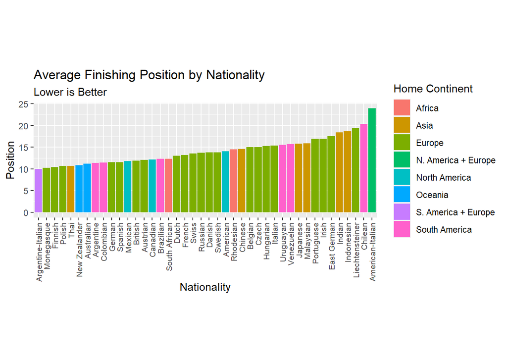

```r
#Create a new dataframe that has only the average position by age
FinishPositionbyCountry <- DriverAge %>%
  group_by(nationality) %>%
  summarise_at(vars(positionOrder), list(name = mean)) %>% rename(position = name)

#Create Continents table to simplify coding them later
Continent <- c(1, 2, 3, 4, 5, 6, 7, 8)
ContinentName <- c("Africa", "Asia", "Europe", "North America", "Oceania", "South America", "N. America + Europe", "S. America + Europe")
Continents <- data.frame(ContinentName, Continent)

#Add a continent column for each nationality
FinishPositionbyCountry$Continent <- c(4, 7, 6, 8, 5, 3, 3, 6, 3, 4, 6, 2, 6, 3, 3, 3, 3, 3, 3, 3, 3, 2, 2, 3, 3, 2, 3, 2, 4, 3, 5, 3, 3, 1, 3, 1, 3, 3, 3, 2, 6, 6)

#Merge dataframes above into one useful dataset
FinishPositionCountryContinent <- merge(FinishPositionbyCountry, Continents, by = 'Continent')



#Create a bar chart, sorted by average finishing position, colored by home continent
CountryPositionPareto <- FinishPositionCountryContinent %>%
  ggplot(aes(x = reorder(nationality, position), y = position, fill = ContinentName)) +
  geom_bar(stat = "identity") +
  labs(title = 'Average Finishing Position by Nationality',
       subtitle = "Lower is Better",
       x = "Nationality",
       y = "Position",) +
  scale_fill_discrete(name = "Home Continent") +
  theme(axis.text.x = element_text(angle = 90, vjust = 0.5, hjust=1, size = 8), aspect.ratio = 1/3)

#View the Plot
CountryPositionPareto
```